# Return Home

[View Code on Github](https://github.com/JohnKimaiyo/Business-Analytics-Power-BI/blob/main/Projects/Webscraping%20Projects/Top%20Court%20Tv%20Shows%20YouTube%20Channels.ipynb)

# Top Court Tv Shows YouTube Channels

## 1 Divorce Court

The venerable courtroom show takes a look at real-life couples. The soon-to-be exes tell their stories to the judge, who gives the ruling and settles all the usual -- and unusual -- divorce issues by the end of the episode. This is the third incarnation of the show titled "Divorce Court," with the first having premiered in 1957.

## 2 Paternity Court

Different from other court shows, "Lauren Lake's Paternity Court" acts only on family issues. There are no battles over rent money or damages caused by a car accident. These emotional cases can have life-changing consequences for participants and sometimes new beginnings for individuals.

## 3 Judge Judy

With her no-nonsense attitude, Judy Sheindlin, a former judge from New York, presides over some real-life small claims cases, where the damages awarded cannot be above $5,000.

## 5 Couples Court

```python
# lets import libraries
from googleapiclient.discovery import build
import pandas as pd
import seaborn as sns
import matplotlib.pyplot as plt
```

## 1 Divorce Court

```python
#  Function to get    Divorce Court Youtube channel statistics

api_key = 'AIzaSyB24Kop04L1GlTgRCm1XtQ4KB2a4gaBOwA'
Divorce_Court_channel_id = ['UCdCj47cPTxr7GxeaBNkRmCA' #  Divorce Court

              ]
youtube = build('youtube','v3',developerKey = api_key)

from googleapiclient.errors import HttpError

def get_channel_stats(youtube, Divorce_Court_channel_id):
    all_data = []
    try:
        request = youtube.channels().list(
            part='snippet,contentDetails,statistics',
            id=','.join(Divorce_Court_channel_id)
        )
        response = request.execute()

        for item in response.get('items', []):
            snippet = item.get('snippet', {})
            statistics = item.get('statistics', {})

            data = {
                'Channel_name': snippet.get('title', ''),
                'Subscribers': statistics.get('subscriberCount', ''),
                'Views': statistics.get('viewCount', ''),
                'Total_videos': statistics.get('videoCount', '')
            }

            all_data.append(data)

    except HttpError as e:
        print(f"HTTP error occurred: {e}")
        print(f"Request URL: {e.resp.request.url}")
        print(f"Request body: {e.resp.request.body}")

    return all_data
```

```python
get_channel_stats(youtube,Divorce_Court_channel_id)
```

```
[{'Channel_name': 'Divorce Court',
  'Subscribers': '955000',
  'Views': '594166254',
  'Total_videos': '5226'}]
```

```python
channel_statistics = get_channel_stats(youtube,Divorce_Court_channel_id )
```

```python
Divorce_Court_channel_data =pd.DataFrame(channel_statistics)
```

```python
Divorce_Court_channel_data
```

|  | Channel_name | Subscribers | Views | Total_videos |
| --- | --- | --- | --- | --- |
| 0 | Divorce Court | 955000 | 594166254 | 5226 |

## 2 Paternity Court

```python
#  Function to get   Paternity Court Youtube channel statistics

api_key = 'AIzaSyB24Kop04L1GlTgRCm1XtQ4KB2a4gaBOwA'
Paternity_Court_channel_id = ['UC5w5rFxcZ4UL_IJSOFWo9OQ' #  Paternity Court

              ]
youtube = build('youtube','v3',developerKey = api_key)

from googleapiclient.errors import HttpError

def get_channel_stats(youtube, Paternity_Court_channel_id):
    all_data = []
    try:
        request = youtube.channels().list(
            part='snippet,contentDetails,statistics',
            id=','.join(Paternity_Court_channel_id)
        )
        response = request.execute()

        for item in response.get('items', []):
            snippet = item.get('snippet', {})
            statistics = item.get('statistics', {})

            data = {
                'Channel_name': snippet.get('title', ''),
                'Subscribers': statistics.get('subscriberCount', ''),
                'Views': statistics.get('viewCount', ''),
                'Total_videos': statistics.get('videoCount', '')
            }

            all_data.append(data)

    except HttpError as e:
        print(f"HTTP error occurred: {e}")
        print(f"Request URL: {e.resp.request.url}")
        print(f"Request body: {e.resp.request.body}")

    return all_data
```

```python
get_channel_stats(youtube,Paternity_Court_channel_id)
```

```
[{'Channel_name': 'Paternity Court',
  'Subscribers': '3390000',
  'Views': '1625906846',
  'Total_videos': '1843'}]
```

```python
channel_statistics = get_channel_stats(youtube,Paternity_Court_channel_id)
```

```python
Paternity_Court_channel_data =pd.DataFrame(channel_statistics)
```

```python
Paternity_Court_channel_data
```

|  | Channel_name | Subscribers | Views | Total_videos |
| --- | --- | --- | --- | --- |
| 0 | Paternity Court | 3390000 | 1625906846 | 1843 |

## 3 Judge Judy

```python
#  Function to get  Judge Judy Youtube channel statistics

api_key = 'AIzaSyB24Kop04L1GlTgRCm1XtQ4KB2a4gaBOwA'
Judge_Judy_channel_id = ['UCzMPPxbQG6iZttQhq3ukXSg' #  Judge Judy

              ]
youtube = build('youtube','v3',developerKey = api_key)

from googleapiclient.errors import HttpError

def get_channel_stats(youtube, Judge_Judy_channel_id):
    all_data = []
    try:
        request = youtube.channels().list(
            part='snippet,contentDetails,statistics',
            id=','.join(Judge_Judy_channel_id)
        )
        response = request.execute()

        for item in response.get('items', []):
            snippet = item.get('snippet', {})
            statistics = item.get('statistics', {})

            data = {
                'Channel_name': snippet.get('title', ''),
                'Subscribers': statistics.get('subscriberCount', ''),
                'Views': statistics.get('viewCount', ''),
                'Total_videos': statistics.get('videoCount', '')
            }

            all_data.append(data)

    except HttpError as e:
        print(f"HTTP error occurred: {e}")
        print(f"Request URL: {e.resp.request.url}")
        print(f"Request body: {e.resp.request.body}")

    return all_data
```

```python
get_channel_stats(youtube,Judge_Judy_channel_id )
```

```
[{'Channel_name': 'Judge Judy',
  'Subscribers': '730000',
  'Views': '814015576',
  'Total_videos': '2384'}]
```

```python
channel_statistics = get_channel_stats(youtube,Judge_Judy_channel_id )
```

```python
Judge_Judy_channel_data =pd.DataFrame(channel_statistics)
```

```python
Judge_Judy_channel_data
```

|  | Channel_name | Subscribers | Views | Total_videos |
| --- | --- | --- | --- | --- |
| 0 | Judge Judy | 730000 | 814015576 | 2384 |

## 4 Judge Marthis

```python
#  Function to get  Judge Marthis Youtube channel statistics

api_key = 'AIzaSyB24Kop04L1GlTgRCm1XtQ4KB2a4gaBOwA'
Judge_Marthis_channel_id = ['UCd_RIVeXkpOSrUfyMR8ktfA' #  Judge Marthis

              ]
youtube = build('youtube','v3',developerKey = api_key)

from googleapiclient.errors import HttpError

def get_channel_stats(youtube, Judge_Marthis_channel_id):
    all_data = []
    try:
        request = youtube.channels().list(
            part='snippet,contentDetails,statistics',
            id=','.join(Judge_Marthis_channel_id)
        )
        response = request.execute()

        for item in response.get('items', []):
            snippet = item.get('snippet', {})
            statistics = item.get('statistics', {})

            data = {
                'Channel_name': snippet.get('title', ''),
                'Subscribers': statistics.get('subscriberCount', ''),
                'Views': statistics.get('viewCount', ''),
                'Total_videos': statistics.get('videoCount', '')
            }

            all_data.append(data)

    except HttpError as e:
        print(f"HTTP error occurred: {e}")
        print(f"Request URL: {e.resp.request.url}")
        print(f"Request body: {e.resp.request.body}")

    return all_data
```

```python
get_channel_stats(youtube,Judge_Marthis_channel_id)
```

```
[{'Channel_name': 'Judge Mathis',
  'Subscribers': '612000',
  'Views': '678619290',
  'Total_videos': '6248'}]
```

```python
channel_statistics = get_channel_stats(youtube,Judge_Marthis_channel_id )
```

```python
Judge_Marthis_channel_data =pd.DataFrame(channel_statistics)
```

```python
Judge_Marthis_channel_data
```

|  | Channel_name | Subscribers | Views | Total_videos |
| --- | --- | --- | --- | --- |
| 0 | Judge Mathis | 612000 | 678619290 | 6248 |

## 5 Couples Court

```python
#  Function to get   Couples Court Youtube channel statistics

api_key = 'AIzaSyB24Kop04L1GlTgRCm1XtQ4KB2a4gaBOwA'
Couples_Court_channel_id = ['UCis8-aFFycLZgNI4bqNcE5g' #  Couples Court

              ]
youtube = build('youtube','v3',developerKey = api_key)

from googleapiclient.errors import HttpError

def get_channel_stats(youtube,Couples_Court_channel_id):
    all_data = []
    try:
        request = youtube.channels().list(
            part='snippet,contentDetails,statistics',
            id=','.join(Couples_Court_channel_id)
        )
        response = request.execute()

        for item in response.get('items', []):
            snippet = item.get('snippet', {})
            statistics = item.get('statistics', {})

            data = {
                'Channel_name': snippet.get('title', ''),
                'Subscribers': statistics.get('subscriberCount', ''),
                'Views': statistics.get('viewCount', ''),
                'Total_videos': statistics.get('videoCount', '')
            }

            all_data.append(data)

    except HttpError as e:
        print(f"HTTP error occurred: {e}")
        print(f"Request URL: {e.resp.request.url}")
        print(f"Request body: {e.resp.request.body}")

    return all_data
```

```python
get_channel_stats(youtube,Couples_Court_channel_id)
```

```
[{'Channel_name': 'Couples Court',
  'Subscribers': '395000',
  'Views': '169032462',
  'Total_videos': '669'}]
```

```python
channel_statistics = get_channel_stats(youtube,Couples_Court_channel_id )
```

```python
Couples_Court_channel_data =pd.DataFrame(channel_statistics)
```

```python
Couples_Court_channel_data
```

|  | Channel_name | Subscribers | Views | Total_videos |
| --- | --- | --- | --- | --- |
| 0 | Couples Court | 395000 | 169032462 | 669 |

```python
# Combine DataFrames using concat
combined_court_channels_df = pd.concat([
                                  Divorce_Court_channel_data ,
                                      Paternity_Court_channel_data,
                                       Judge_Judy_channel_data,
                                      Judge_Marthis_channel_data ,
                                       Couples_Court_channel_data,


                                      ], ignore_index=True)

# Display the result
print(combined_court_channels_df)
```

```
      Channel_name Subscribers       Views Total_videos
0    Divorce Court      955000   594166254         5226
1  Paternity Court     3390000  1625906846         1843
2       Judge Judy      730000   814015576         2384
3     Judge Mathis      612000   678619290         6248
4    Couples Court      395000   169032462          669
```

```python
# lets change the datatypes to perform  visualisations
combined_court_channels_df['Subscribers'] = pd.to_numeric(combined_court_channels_df['Subscribers'])
combined_court_channels_df['Views'] = pd.to_numeric(combined_court_channels_df['Views'])
combined_court_channels_df['Total_videos'] = pd.to_numeric(combined_court_channels_df['Total_videos'])
# letsconirm if the datatypes has changed
combined_court_channels_df.info()
```

```
<class 'pandas.core.frame.DataFrame'>
RangeIndex: 5 entries, 0 to 4
Data columns (total 4 columns):
 #   Column        Non-Null Count  Dtype
---  ------        --------------  -----
 0   Channel_name  5 non-null      object
 1   Subscribers   5 non-null      int64
 2   Views         5 non-null      int64
 3   Total_videos  5 non-null      int64
dtypes: int64(3), object(1)
memory usage: 292.0+ bytes
```

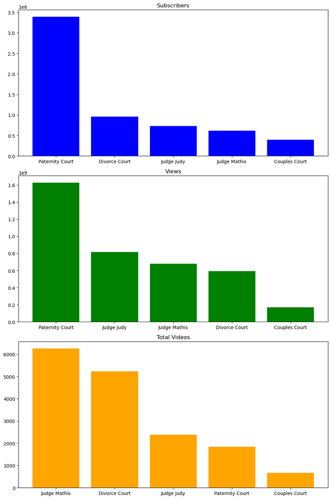

```python
import matplotlib.pyplot as plt

# Sort the DataFrame by 'Subscribers' in descending order
combined_court_channels_df_subscribers_sorted = combined_court_channels_df.sort_values(by='Subscribers', ascending=False)

# Plotting Subscribers in descending order
fig, axes = plt.subplots(nrows=3, ncols=1, figsize=(10, 15))

axes[0].bar(combined_court_channels_df_subscribers_sorted['Channel_name'],combined_court_channels_df_subscribers_sorted['Subscribers'], color='blue')
axes[0].set_title('Subscribers')

# Sort the DataFrame by 'Views' in descendcombined_real_estate_channels_dfing order
combined_court_channels_df_views_sorted = combined_court_channels_df.sort_values(by='Views', ascending=False)

# Plotting Views in descending order
axes[1].bar(combined_court_channels_df_views_sorted['Channel_name'],combined_court_channels_df_views_sorted['Views'], color='green')
axes[1].set_title('Views')

# Sort the DataFrame by 'Total_videos' in descending order
combined_court_channels_df_total_videos_sorted = combined_court_channels_df.sort_values(by='Total_videos', ascending=False)

# Plotting Total Videos in descending order
axes[2].bar(combined_court_channels_df_total_videos_sorted['Channel_name'], combined_court_channels_df_total_videos_sorted['Total_videos'], color='orange')
axes[2].set_title('Total Videos')

# Adjust layout for better visibility
plt.tight_layout()

# Show the plot
plt.show()
```